# Geopolitical Risk (GPR) Index

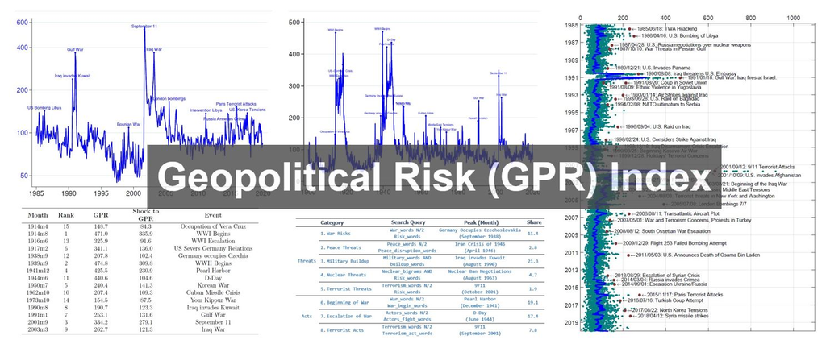

## **Overview and Paper**

#### Dario Caldara and Matteo Iacoviello construct a measure of adverse geopolitical events and associated risks based on a tally of newspaper articles covering geopolitical tensions, and examine its evolution and economic effects since 1900. The geopolitical risk (GPR) index spikes around the two world wars, at the beginning of the Korean War, during the Cuban Missile Crisis, and after 9/11. Higher geopolitical risk foreshadows lower investment, stock prices, and employment. Higher geopolitical risk is also associated with higher probability of economic disasters and with larger downside risks to the global economy.

#### The Recent GPR Index uses 10 newspapers and starts in 1985. The Historical Index uses 3 newspapers and starts in 1900. **Country-specific indexes** are also constructed for 44 different countries.

#### A presentation summarizing our work can be found here. We welcome kudos, comments, and suggestions! Contact matteo.iacoviello@frb.gov.

#### Cite as: Caldara, Dario and Matteo Iacoviello (2022), “Measuring Geopolitical Risk,” American Economic Review, April, 112(4), pp.1194-1225.

##### (When using the data, we suggest referring to both the website and the date of download; e.g. “Data downloaded from https://www.matteoiacoviello.com/gpr.htm on Month DD, YYYY”).

#### An online appendix to the paper is available [here](https://www.matteoiacoviello.com/gpr_files/GPR_APPENDIX.pdf).

#### The search terms of the index were last changed in 2021 and incorporate a slightly different methodology relative to the old (2018) index (GPR_OLD).

#### The replication material of the published paper is available on the AEA repository at the following [link](https://www.openicpsr.org/openicpsr/project/154781/version/V1/view). Quick access to the replication material can also be found at the following link.

## **Description**

#### The Caldara and Iacoviello GPR index is based on searches of the archives of 10 newspapers: Chicago Tribune, the Daily Telegraph, Financial Times, The Globe and Mail, The Guardian, the Los Angeles Times, The New York Times, USA Today, The Wall Street Journal, and The Washington Post. Caldara and Iacoviello calculate the index by counting the number of articles related to adverse geopolitical events in each newspaper for each month (as a share of the total number of news articles). The search is organized in eight categories: War Threats (Category 1), Peace Threats (Category 2), Military Buildups (Category 3), Nuclear Threats (Category 4), Terror Threats (Category 5), Beginning of War (Category 6), Escalation of War (Category 7), Terror Acts (Category 8). Based on the search groups above, Caldara and Iacoviello also constructs two subindexes. The Geopolitical Threats (GPRT) includes words belonging to categories 1 to 5 above. The Geopolitical Acts (GPRA) index includes words belonging to categories 6 to 8.

## **Data**

#### Download our monthly data here: Excel format; Stata format The monthly data are updated at the beginning of each month.* (Last update: October 1, 2026). The monthly data include the country-specific GPR indexes. Each series mnemonics is described in the last columns of the Excel file and in the Stata file.

#### Daily data for the Recent GPR index are available here: Excel format; Stata format *The daily data are updated every Monday.* (Last update: October 26, 2026)*

##### *If the first day of the month or week falls on a federal holiday, data updates will take place the next business day.

#### Access older vintages of the data [here](https://github.com/iacoviel/iacoviel.github.io/tree/master/gpr_archive_files).

#### A log of past updates to the data can be found [here](https://github.com/iacoviel/iacoviel.github.io/blob/master/gpr_files/log.txt).

###### Monthly vintages are named as follows, where YYYYMM are the year and month of the update version: Excel format: data_gpr_export_YYYYMM.xls Stata format: data_gpr_export_YYYYMM.dta Daily vintages are named as follows, where YYYYMMDD are the year, month, and day of the update version: Excel format: data_gpr_daily_recent_YYYYMMDD.xls Stata format: data_gpr_daily_recent_YYYYMMDD.dta Note: The latest data are preliminary and subject to revisions since some newspapers are added to the search database with delay. Additionally, in some cases there could be minor revisions of the data extending further back when duplicate or missing articles or newspaper editions are removed from or added to the database.

## **Charts of the GPR Index**

#### Charts of the country-specific indexes can be found here.

- Daily
- Log Daily
- Recent
- Historical
- Recent Threats & Acts
- Historical Threats & Acts
- Subcategories of Hist. Index

[interactive chart not shown]

Note: Move the slider below the chart to zoom in on a specific date range. Click and drag a square around any area to zoom in further. Double click the chart to zoom back out. Select or deselect individual series to compare GPR indexes. Double click to isolate one series and again to select all series. Log scales of indexes refer to log(1+GPR) of the corresponding GPR index.

License: All the material in this webpage, including interactive visualizations and code, are completely open access under the [Creative Commons BY license](https://creativecommons.org/licenses/by/4.0/). You have the permission to use, distribute, and reproduce these in any medium, provided the source and authors are credited.  
This webpage is maintained by Lilliana Wells, Will Yang, Sam Nate, and Matteo Iacoviello.